# Ch6. Inferring a Binomial Probability via Exact Mathematical Analysis

- Date: Mar 18th, 2015
- Created by: Jungwon Choi

*program needed in the book: https://sites.google.com/site/doingbayesiandataanalysis/software-installation/DBDA2Eprograms.zip?attredirects=0&d=1

## 0. 이거 왜 하나?

#### *Pure analytical mathematics* 을 이용한 베이지안 추론

- 일부 단순하고, 이상적인 상황에만 적용가능
- 따라서, 복잡한 분포 가정에서는 사용하기 힘들다 (approximation 필요. 예, MCMC)
- 그러나, “연속형 파라미터에 대해서 베이지안 추론”이 무엇인지에 대한 감을 잡는 데에는 유용함
- likelihood 가 *conjugate* prior distrubution을 가지고 있는 경우 에대해서만 논의하겠다. (특히 이 챕터에서는 **beta distribution**의 경우만)

#### recall:

Bayesian Framework prior + data(observation) -> posterior distribution

’동전 던지는 상황’으로 내용을 이해해 보자.

## 1. Likelihood Fuction

recall:

**Bernoulli distribution** $latex p(y|\theta) = \theta ^{y}(1-\theta) ^ {(1-y)}$

two way of interpreting this - a **probability distrubution**: y a random variable, and $\theta$ a fixed parameter - a **likelihood function** : y a fixed observation, and $\theta$ a random variable $p(\left \{ y_{i} \right \}|\theta) = \prod_{i}p(y_{i}|\theta) \\=\prod_{i}\theta^{y_{i}}(1-\theta)^{(1-y_{i})}\\=\theta^{\sum_{i}y_{i}}(1-\theta)^{\sum_{i}(1-y_{i})} \\= \theta^{z}(1-\theta)^{N-z}$

## 2. Prior나타내기: Beta Distribution

- interval (0,1) 사이의 값을 가지는 $\theta$대한 prior probability를 나타낼 수있는 식이 필요함
- 이 챕터에서처럼 수학적으로 계산이 가능하려면: 다음 베이즈정리의 식에서 $p(\theta|y) = \frac{p(y|\theta)p(\theta)}{\int p(y|\theta)p(\theta)d\theta }$
1. 분자부분: 서로같은 형태의 prior $p(\theta)$와 likelihood인 $p(y|\theta)$가 곱해지면 같은 형태의 결과가 나올 것이다  
   $p(\theta)$는 $p(y|\theta)$에 대한_conjugate prior_의 형태여야함
2. 분모부분: 적분 가능해야 함

다시 Bernoulli 분포 상황으로 돌아가서, 우리는 prior가 $\theta^{a}(1-\theta)^{b}$와 같이 생겼을 때, Bernoulli 형태의 likelihood를 곱하면, 다시 posterior 분포도 Bernoulli의 형태를띌 것이다.  
이러한 특성을 가지는 분포가 Beta 분포!

**Beta *distribution*** $latex p(y|a,b) = beta(y|a,b) = \theta ^{(a-1)}(1-\theta) ^ {(b-1)}/B(a,b)$ where $B(a,b)$ a normalizing constant

**cf. Beta *function*** $latex B(a,b) = \int_{0}^{1}\theta ^{(a-1)}(1-\theta) ^ {(b-1)}d\theta$ where$0\leq\theta\leq1,\\ a>0\;and\;b>0$

compare with r function

```r
x <- seq(0, 1, length = 21)
dbeta(x, 2, 2)
```

```
##  [1] 0.000 0.285 0.540 0.765 0.960 1.125 1.260 1.365 1.440 1.485 1.500
## [12] 1.485 1.440 1.365 1.260 1.125 0.960 0.765 0.540 0.285 0.000
```

```r
beta(2,2)
```

```
## [1] 0.1667
```

### (1) beta prior 지정하기

- $\theta$에 대한 우리의 믿음(belief) 반영하기
- 동전던지기 상황을 다시 떠올려서…
- 사전적으로 a=앞면의 개수 b=뒷면의 개수로 이루어진 총 n번의 시행이 있었다고 가정하자.

beta distribution의특성

mean: $\mu = a/(a+b)$  
mode: $\omega = (a-1)/(a+b-2)$  
for a>1 and b>1

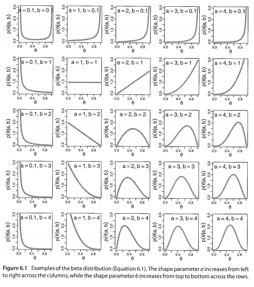

concentration  
$\kappa = a+b$

a and b, in terms of kappa, mean and mode  
$a=\mu\kappa\;\;and\;\;b=(1-\mu)\kappa\\a=\omega(\kappa-2)+1\;\;and\;\;b=(1-\omega)(\kappa-2)+1\;\;for\;\;\kappa>2$

```r
source("DBDA2E-utilities.R")
```

```
##
## Kruschke, J. K. (2015). Doing Bayesian Data Analysis, Second Edition:
## A Tutorial with R, JAGS, and Stan. Academic Press / Elsevier.
```

```r
betaABfromMeanKappa(mean=0.25,kappa=4)
```

```
## $a
## [1] 1
##
## $b
## [1] 3
```

```r
betaABfromModeKappa(mode=0.25,kappa=4)
```

```
## $a
## [1] 1.5
##
## $b
## [1] 2.5
```

```r
betaABfromMeanSD(mean=0.5,sd=0.1)
```

```
## $a
## [1] 12
##
## $b
## [1] 12
```

```r
betaParam = betaABfromModeKappa(mode=0.25,kappa=4)
betaParam$a
```

```
## [1] 1.5
```

```r
betaParam$b
```

```
## [1] 2.5
```

## 3. The Posterior Beta

prior를 지정하였으면 Bayes Rule로 posterior가 어떠할지 파악해보자 $N$번의 동전던지기 시행 중 $z$번의 앞면이 나왔다고 하면, 베이즈 정리에 따라

$p(\theta|z,N) = p(z,N|\theta)p(\theta)/p(z,N)\\=\theta^{z}(1-\theta)^{(N-z)}\frac{\theta^{(a-1)}(b-1)^{(b-1)}}{B(a,b)}/p(z,N)\\=\theta^{z}(1-\theta)^{(N-z)}\theta^{(a-1)}(b-1)^{(b-1)}/\left [ B(a,b)p(z,N)) \right ]\\=\theta^{((z+a)-1)}(1-\theta)^{((N-z+b)-1)}/\left [ B(a,b)p(z,N)) \right ]\\=\theta^{((z+a)-1)}(1-\theta)^{((N-z+b)-1)}/B(z+a,N-z+b)$

동전던지기의 예로 생각해보면:  
- prior는 beta($\theta$|1,1) - 동전을 던졌더니 앞면이 나왔다 - posterior는 beta($\theta$|2,1) - 동전을 또 던졌더니 뒷면이 나왔다 - 업데이트된 posterior는 beta($\theta$|2,2) … prior가 beta distribution이면 prior도 항상 beta distribution임을 확인할 수 있다.

### (1) posterior distribution은 prior와 likelihood의 타협이다

동전의 예로 mean을 계산하는 경우를 생각해보면, $\frac{z+a}{N+a+b} = \frac{z}{N}\frac{N}{N+a+b}+\frac{a}{a+b}\frac{a+b}{N+a+b}$

## 4. Example

### (1) 베타분포로 prior를 나타낼 수 있을 때

<상황> - 갓만든 신선한 정상 동전 - 나의 굳은 믿음으로 mode는 0.5이고, 유효한 샘플 수는 500이라고 가정한다 - 20번 동전을 던져서 17번(85%) 앞면이나옴 - 이 때, 앞면이 나올 확률의 기대값은?

```r
source("DBDA2E-utilities.R")  # Load definitions of graphics functions etc.
```

```
##
## Kruschke, J. K. (2015). Doing Bayesian Data Analysis, Second Edition:
## A Tutorial with R, JAGS, and Stan. Academic Press / Elsevier.
```

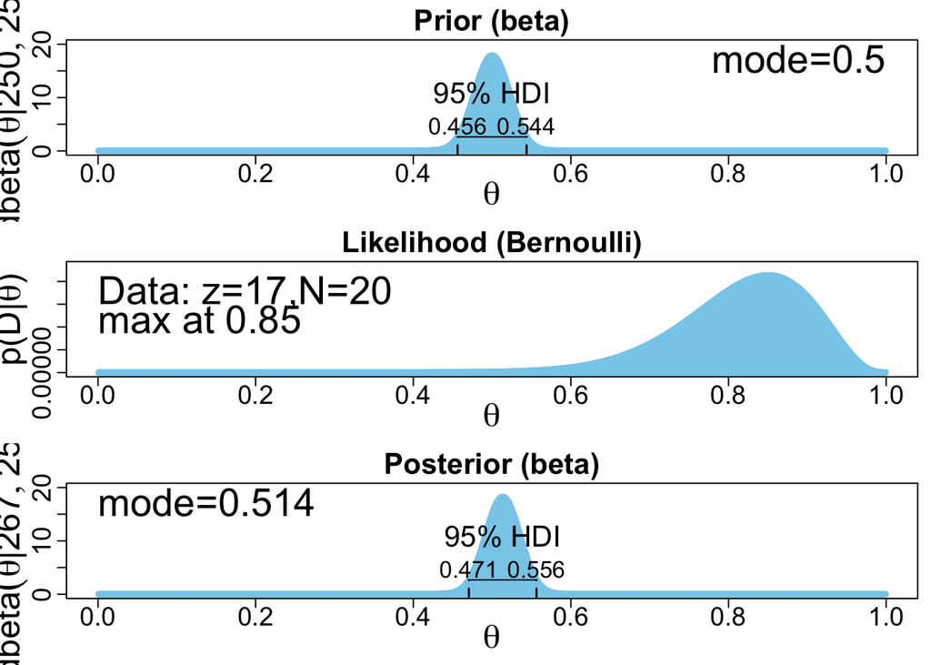

```r
source("BernBeta.R")          # Load the definition of the BernBeta function

# Specify the prior:
t = 0.5             # Specify the prior MODE.
n = 500              # Specify the effective prior sample size.
a = t*(n-2) + 1      # Convert to beta shape parameter a.
b = (1-t)*(n-2) + 1  # Convert to beta shape parameter b.

Prior = c(a,b)       # Specify Prior as vector with the two shape parameters.

# Specify the data:
N = 20                         # The total number of flips.
z = 17                         # The number of heads.
Data = c(rep(0,N-z),rep(1,z))  # Convert N and z into vector of 0's and 1's.

openGraph(width=5,height=7)
posterior = BernBeta( priorBetaAB=Prior, Data=Data , plotType="Bars" ,
                      showCentTend="Mode" , showHDI=TRUE , showpD=FALSE )
```

```r
saveGraph(file="BernBetaExample",type="png")
```

위의 예제를 활용해서 다양한 상황에 응용할 수 있다.

### (2) 베타분포로 prior를 나타낼 수 없는 경우

<상황> - 이상한 회사에서 2가지 동전을 생산한다: 앞면이 나올 확률이 25%인 동전과, 앞면이 나올 확률이 75%인 동전 - 이 때, prior distribution은 bimodal한 형태를 띠게 됨

(다시 grid approxomation으로…)

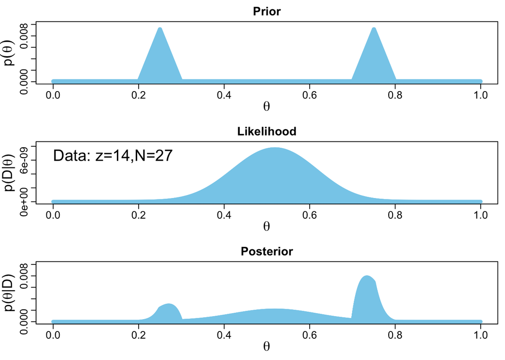

```r
source("BernBeta.R")
source("BernGrid.R")

Theta <- seq(0,1,length=1000)
pTheta <- c(rep(1,200),seq(1,100,length=50),seq(100,1,length=50),rep(1,200),
           rep(1,200),seq(1,100,length=50),seq(100,1,length=50),rep(1,200))
pTheta <- pTheta/sum(pTheta)



Data <- c(rep(0,13),rep(1,14))
posterior <- BernGrid(Theta, pTheta,Data,plotType="Bars",
                      showCentTend="None", showHDI=FALSE, showpD=FALSE)
```